# EDA: Biodiversity sighting in Gippsland

Author

Huyen-Anh Pham - 33429839

Published

September 12, 2024

# Introduction

This data visualisation project aims to explore the biodiversity and wildfire impacts in Gippsland, Victoria, Australia by visualising the species sighting and fire records. The East Gippsland suffered from wildfires in the season of 2019/2020 (Department of Environment and Planning 2020). The motivation behind the analysis is the [Life After Fire (LAF) project](https://vnpa.org.au/life-after-fire/) - a nature conservative response by the Victorian National Parks Association. Inspired by the LAF project’s goals of monitoring wildlife survival and habitat recovery, this data exploration (DEP) project seeks to answer the following questions:

**Questions**

Q1. What are the species groups sighted in Gippsland LAF project area?  
Q2. How does the sighting change over time?  
Q3. How was the sighting affected by fire?

# Data Wrangling

**About the Data**

Refer to the Appendix’s Table 1 and Table 2 for the data dictionary of the datasets.

Other supplementary data used in this project are:

- Victoria shapefile map (Statistical Areas Level 2 - 2021 GDA2020) from the Australian Bureau of Statistics ([ABS](https://www.abs.gov.au/statistics/standards/australian-statistical-geography-standard-asgs-edition-3/jul2021-jun2026/access-and-downloads/digital-boundary-files#cite-window1)) (Statistics 2021-2026).
- Parks and Conservation Reserves shapefile from the Department of Energy, Environment and Climate Action ([DEECA](https://discover.data.vic.gov.au/dataset/parks-and-conservation-reserves-parkres)) (Department of Energy and Action 2024).

The report is produced using R (Team 2024) via RStudio (team 2024) and these R packages: `galah` (Westgate et al. 2024), `tidyverse` (Wickham et al. 2019), `visdat` (Tierney 2017), `sf` (Pebesma 2018), `ggsankey` (Sjoberg 2024), `RColorBrewer` (Neuwirth 2022), `patchwork` (Pedersen 2024), `units` (Pebesma, Mailund, and Hiebert 2016), `TinyTeX` (Xie 2019), `knitr` (Xie 2024), and `kableExtra` (Zhu 2024).

**Data Wrangling**

These following data wrangling steps were performed to prepare the data for exploration:

**A. Sighting records**

- Subset by time and space: sighting records between 2017 to 2022 and within the LAF project.
- Mutate values of `speciesGroup` column into common species group names. Top 5 species groups are: *Birds*, *Plants*, *Mammals*, *Amphibians*, and *Insects*. Other species groups are grouped into *Others*.
- Remove invalid records (`speciesGroup` is NA).
- Convert dataset into `sf` object for spatial visualisation.
- Handling date-time variable by adding new temporal columns: `eventYear`, `eventMonth`.
- Remove unused column: `eventTime`, `recordedBy`.

**B. Fire History**

- Subset fire records that intersected with the LAF project area, and fire start date is between Nov 2019 and Feb 2020.
- Remove unused column. The remaining columsn are: `FIRE_SEASON`, `FIRE_NO`, `FIRE_NAME`, `START_DATE`, and `geometry`.

# Data Checking

- Sensibility checking for the coordinates find no invalid value (Figure 8).
- Missing values: Using R library `visdat` to check for missing values in the dataset.
  - A. Sighting (Figure 1): Values for the species taxonomy columns are not always recorded. 94% of the `eventTime` records are missing. 42% of the `recordedBy` records are missing.
  - B. Fire (Figure 2): No missing values in columns needed in this analysis.
- Date format checking: both datasets have the appropriate date values.
- Checking for outliers in sighting daily count (Figure 6). There are some outliers with more than 1,000 records per day in *Plants* species group. These outliers are from the *Victorian Biodiversity Atlas* and not errors, but could be due to the high demand in sighting these species for researching purposes.

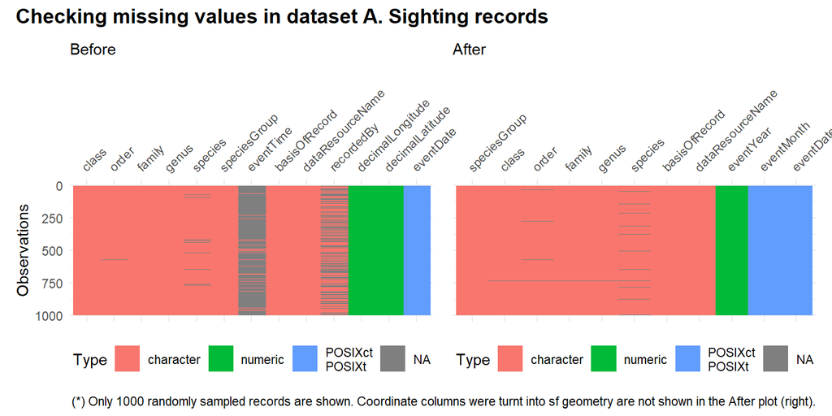

Figure 1: Visualisation of missing values in dataset A. Sighting records

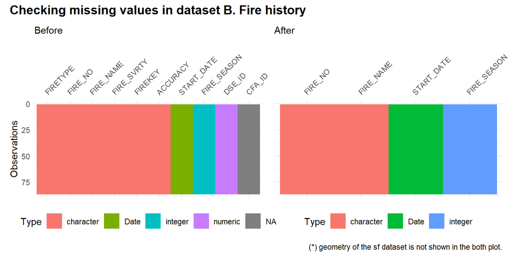

Figure 2: Visualisation of missing values in dataset B. Fire history

# Data Exploration

## Fire

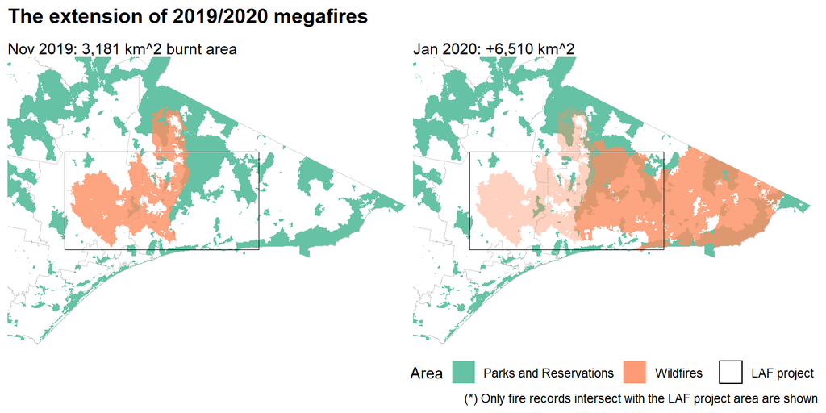

Figure 3: The extension of 2019/2020 megafires across the Gippsland LAF project area.

There were two major outburst of fire in the LAF project area during the megafires 2019/2020. The first one started in 22 November 2019 and the second one started in January 2020. The second outburst was twice more extensive than the first one, reached to more parks and reservation areas. More than 80% of the LAF project area was damaged by the wildfires (Figure 3).

## Sightings

### What are the species groups sighted in Gippsland?

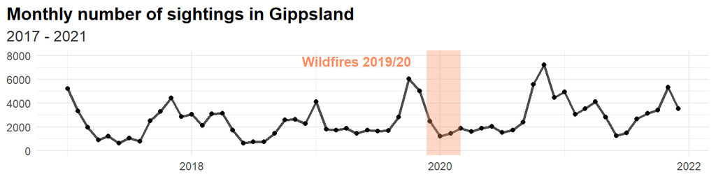

Figure 4: Monthly sightings in Gippsland from 2017 to 2021

First, the analysis of aggregated monthly sighting data reveals a cyclical pattern, with significantly lower sightings during the winter months and higher counts in the summer. As illustrated in (Figure 4), this trend is consistent across multiple years. To gain a more accurate understanding of long-term trends, we then aggregating sighting records by year.

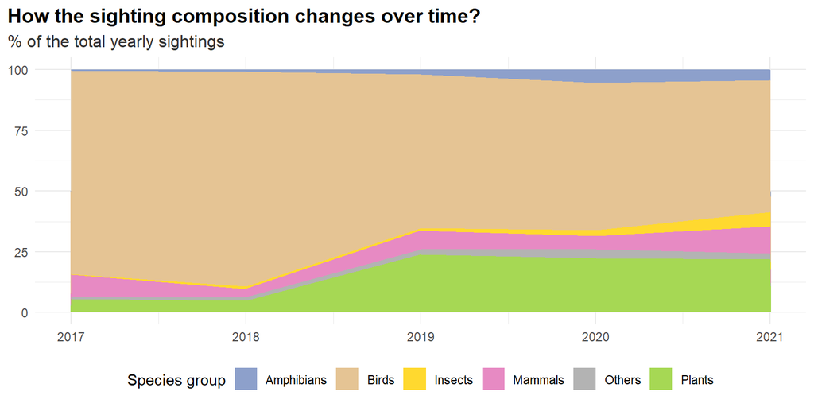

Figure 5: The composition of species groups sighted in Gippsland from 2017 to 2021.

**What are the species groups sighted in Gippsland?**

There are five main species groups sighted in Gippsland LAF project area: *Amphibians*, *Birds*, *Insects*, *Mammals*, *Plants*. Species groups with low number of yearly sightings are classified as *Others*.

**How does the sighting change over time?**

Prior to the 2019/2020 megafires, *Birds* sightings dominated the Gippsland region, constituting 84% and 88% of all sightings in 2017 and 2018, respectively. However, post-fire data reveals a shift in the distribution of sightings. While the proportion of *Birds* sightings decreased, there was a significant increase in sightings of *Plants*, *Mammals* and *Insects*, suggesting an increase in data collection for the ecological recovery research.

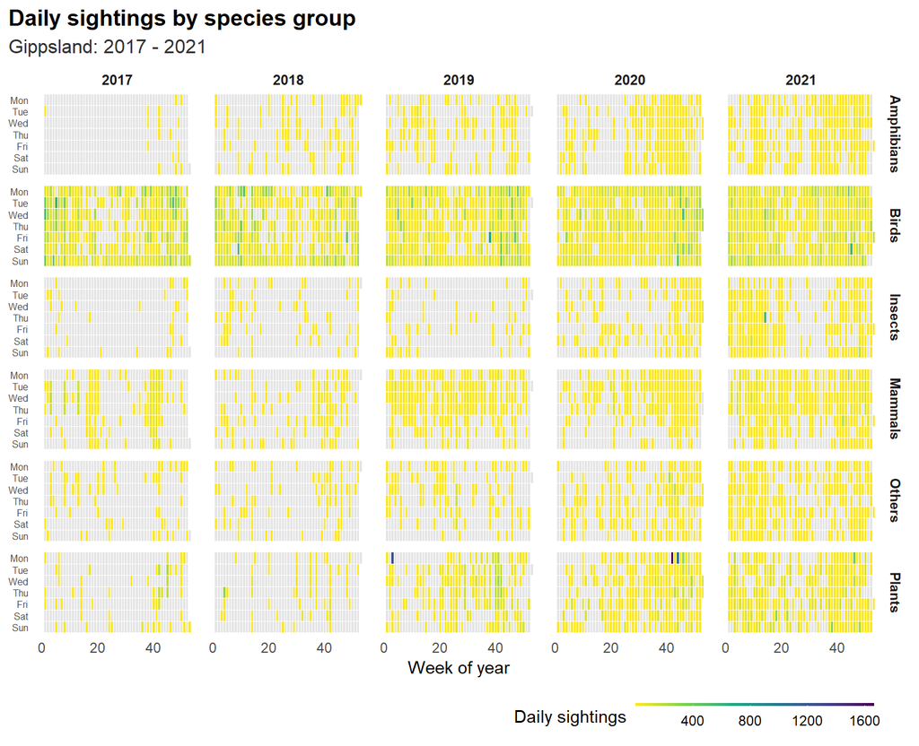

Figure 6: Daily sightings by species group in Gippsland from 2017 to 2021

**When did we sight these species groups?**

Figure 6 presents the daily sightings by each species group. *Birds* sightings are more frequent during summer months. In 2017 *Mammals* sightings, there are two time periods with consistently daily sightings. Since 2019, interest in sighting *Mammals* spread out more evenly throughout the year. In *Plants* sightings, there are three outliers with particularly high daily sightings: one in January 2019, the other two in October and November 2020.

### How do we sight the species?

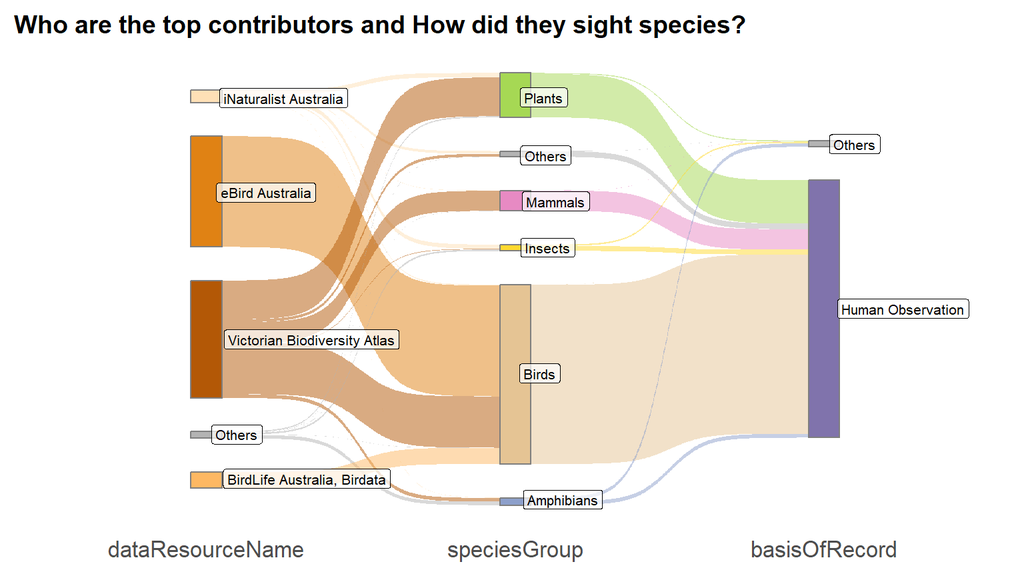

Figure 7: Data sources and recording basis of the sightings in Gippsland from 2017 to 2021.

Figure 7 reveals the top data contributors to be *Victorian Biodiversity Atlas (VBA)*, *eBird Australia*, *BirdLife Australia, Birdata*, and *iNaturalist Australia*. The most contributive organisation, VBA, has its sighting effort distributed across all species groups, while the 2nd and 3th runner-up, *eBird Australia* and *BirdLife Australia, Birdata*, mainly focus on sighting *Birds*. *Human Observation* is the main basis of recording, accounts for 98% of the total sightings. All *Birds* sightings are recorded by *Human Observation* method.

### Where are the sightings located?

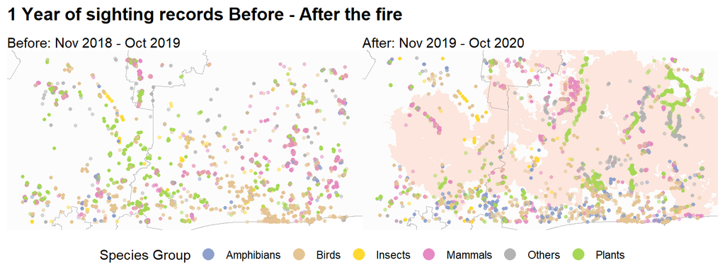

Figure 8: Each individual sighting record a year before and after the wildfires in Gippsland.

The pre-fire *Plants* sightings were concentrated in the western part of the LAF project area while *Birds* usually found along the eastern coastal line. A year after the fire, there were significantly more sighting effort of *Plants* and *Mammals* in the fire-affected area with some geographical clustering and pattern. The sighting trails of *Plants* might reflect the trekking route taken by sighter. More *Amphibians* were sighted along the southern coastal unburned area.

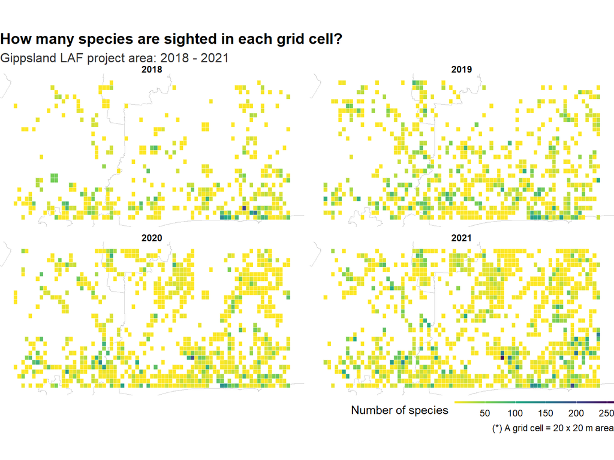

To assess the species richness (Moore 2013) in Gippsland LAF project area, spatial aggregation is performed using rasterising and operations supported by the `sf` R package.

Figure 9 demonstrates that more species are found in the southern part of the project area. Richness hotspot is located at the south-eastern area (bottom right) where more than 200 species are sighted within a cell. However, more coloured cell appear after the 2019/2020 wildfires does not mean the species richness is higher. This only reflects the increased sighting effort in the both burnt and unburnt area.

# Conclusion

**Q1. What are the species groups sighted in the Gippsland LAF project area?**

The visual analysis reveals that the *Birds* species group dominated the Gippsland research region.

**Q2. How does the sighting change over time?**

The monthly number of sightings follow a cyclical pattern, with significantly lower sightings during the winter months and higher counts in the summer.

**Q3. How was the sighting affected by fire?**

The wildfires triggered a shift in the distribution of sightings. The proportion of *Birds* sightings decreased, while the sightings of *Plants*, *Mammals*, and *Insects* increased over time. After-fire responses help increased the sighting effort in the area, shedding light on the biodiversity status and recovery process.

# Reflection

**Limitation of chosen datasets**

The most significant limitation of the voluntary observational data is that sightings are arbitrary events and may be influenced by numerous factors outside the scope of our dataset. There may also be observer bias in our dataset, as birdwatchers who actively seek out these birds are more likely to go out during specific hours of the day that align with their own schedules. Additionally, the observational nature of sighting data prevents us from applying model-fitting procedures for this analysis.

Another limitation of the Sighting dataset is missing or unreliable date-time values. This lack of date-time information hinders futher spatio-temporal analysis, which is essential for biodiversity understanding.

The Fire dataset inherits some limitations from the raw Fire history data source, as fire severity are not available for all records. This limits our ability to assess the relationship between fire severity and species richness.

# Appendix

Table 1: Data Dictionary - Dataset A. Sighting records

|  | Variable | Type | Description |
| --- | --- | --- | --- |
| 1 | speciesGroup | character | Species group |
| 2 | class | character | Taxonomic class |
| 3 | order | character | Taxonomic order |
| 4 | family | character | Taxonomic family |
| 5 | genus | character | Taxonomic genus |
| 6 | species | character | Taxonomic specific species |
| 7 | basisOfRecord | character | The specific nature of the data record (i.e. Human Observation, Machine Observation, Fossil Specimen, etc.) |
| 8 | dataResourceName | character | The data resource that supplies the record |
| 9 | eventYear | numeric | Sighting event Year |
| 10 | eventMonth | POSIXct, POSIXt | Sighting event Month |
| 11 | eventDate | POSIXct, POSIXt | Sighting event Date |
| 12 | geometry | sfc_POINT, sfc | Coordinates associated with the sighting record |

Table 2: Data Dictionary - Dataset B. Fire history

|  | Variable | Type | Description |
| --- | --- | --- | --- |
| 1 | FIRE_SEASON | integer | Fire season (Year) |
| 2 | FIRE_NO | character | Fire Number |
| 3 | FIRE_NAME | character | Fire Name |
| 4 | START_DATE | Date | Fire Start date |
| 5 | geometry | sfc_POLYGON, sfc | Polygon boundary of each fire record |

## Bibliography

ALA. 2024. “Atlas of Living Australia - Occurrence Record Data in Gippsland.” https://doi.org/10.26197/ala.6e0ccfe2-802a-499f-a8d5-2e6f40ce0364. https://doi.org/10.26197/ala.6e0ccfe2-802a-499f-a8d5-2e6f40ce0364.

Department of Energy, Environment, and Climate Action. 2024. “Parks and Conservation Reserves.” https://discover.data.vic.gov.au/dataset/parks-and-conservation-reserves-parkres.

Department of Environment, Water, Land, and Victoria Planning. 2020. “Ecosystem Services from Forests in Victoria: Impact of the 2019–20 Bushfires.” Victorian Government.

———. n.d. “Fire History Overlay of Most Recent Fires.” https://discover.data.vic.gov.au/dataset/fire-history-overlay-of-most-recent-fires.

Moore, John C. 2013. “Diversity, Taxonomic Versus Functional.” In *Encyclopedia of Biodiversity (Second Edition)*, edited by Simon A Levin, Second Edition, 648–56. Waltham: Academic Press. https://doi.org/https://doi.org/10.1016/B978-0-12-384719-5.00036-8.

Neuwirth, Erich. 2022. *RColorBrewer: ColorBrewer Palettes*.

Pebesma, Edzer. 2018. “Simple Features for R: Standardized Support for Spatial Vector Data.” *The R Journal* 10 (1): 439–46. https://doi.org/10.32614/RJ-2018-009.

Pebesma, Edzer, Thomas Mailund, and James Hiebert. 2016. “Measurement Units in R.” *R Journal* 8 (2): 486–94. https://doi.org/10.32614/RJ-2016-061.

Pedersen, Thomas Lin. 2024. *Patchwork: The Composer of Plots*. https://patchwork.data-imaginist.com.

Sjoberg, David. 2024. *Ggsankey: Sankey, Alluvial and Sankey Bump Plots*. https://github.com/davidsjoberg/ggsankey.

Statistics, Australian Bureau of. 2021-2026. “Digital Boundary Files [Internet].” Canberra: ABS. https://www.abs.gov.au/statistics/standards/australian-statistical-geography-standard-asgs-edition-3/jul2021-jun2026/access-and-downloads/digital-boundary-files.

team, Posit. 2024. *RStudio: Integrated Development Environment for r*. Boston, MA: Posit Software, PBC. http://www.posit.co/.

Team, R Core. 2024. *R: A Language and Environment for Statistical Computing*. Vienna, Austria: R Foundation for Statistical Computing. https://www.R-project.org/.

Tierney, Nicholas. 2017. “Visdat: Visualising Whole Data Frames.” *JOSS* 2 (16): 355. https://doi.org/10.21105/joss.00355.

Westgate, Martin, Matilda Stevenson, Dax Kellie, and Peggy Newman. 2024. *Galah: Biodiversity Data from the GBIF Node Network*. https://CRAN.R-project.org/package=galah.

Wickham, Hadley, Mara Averick, Jennifer Bryan, Winston Chang, Lucy D’Agostino McGowan, Romain François, Garrett Grolemund, et al. 2019. “Welcome to the tidyverse.” *Journal of Open Source Software* 4 (43): 1686. https://doi.org/10.21105/joss.01686.

Xie, Yihui. 2019. “TinyTeX: A Lightweight, Cross-Platform, and Easy-to-Maintain LaTeX Distribution Based on TeX Live.” *TUGboat* 40 (1): 30–32. https://tug.org/TUGboat/Contents/contents40-1.html.

———. 2024. *Knitr: A General-Purpose Package for Dynamic Report Generation in r*. https://yihui.org/knitr/.

Zhu, Hao. 2024. *kableExtra: Construct Complex Table with ’Kable’ and Pipe Syntax*. http://haozhu233.github.io/kableExtra/.